# 3 — Inverse Kinematics

Put the foot *there* · SOC4180 Robot and AI

Hong Jeong

## Reversing last week

Last week: **angles in, foot position out.** One answer, always, computed in twelve lines.

This week: **foot position in, angles out.** And now the question misbehaves.

- there may be **no** solution — the target is out of reach
- there may be **many** — knee forward or knee back
- there may be **infinitely many** — more joints than constraints
- near some poses the answer exists but **explodes**

Every one of those is a real situation the Week 4 walker has to survive.

## Nothing is falling today

Inverse kinematics is a statement about **geometry**, not balance. A pose that solves perfectly may be one the robot cannot hold for a moment.

So today we render **kinematics only** — poses placed and drawn, physics never stepped. Nothing falls over, because nothing is being simulated.

Keeping that separation clear now is what lets Week 4 combine them deliberately.

## The easy case: two links in a plane

Ignore the hip’s roll and yaw and the ankle. What is left is a thigh and a shin — two links, one plane — and hip, knee and foot are the corners of a **triangle whose three sides you know**: thigh $\ell_1$, shin $\ell_2$, and the hip-to-foot distance $d$. The law of cosines gives the angle at any corner outright. Written for the **knee joint angle** ${\color{#c0392b}{\theta}}$ — zero when the leg is straight, the way MuJoCo’s knee counts — the triangle’s interior corner is $\pi - {\color{#c0392b}{\theta}}$, and the hip corner ${\color{#2e8b57}{\varphi}}$ comes the same way:

$$\cos{\color{#c0392b}{\theta_{\text{knee}}}} = \frac{d^2 - \ell_1^2 - \ell_2^2}{2\,\ell_1\ell_2},
\qquad
\cos{\color{#2e8b57}{\varphi}} = \frac{\ell_1^2 + d^2 - \ell_2^2}{2\,\ell_1 d}$$

```
thigh  l1 = 0.3409 m
shin   l2 = 0.3000 m
reach is an annulus: 0.0409 m to 0.6409 m
```

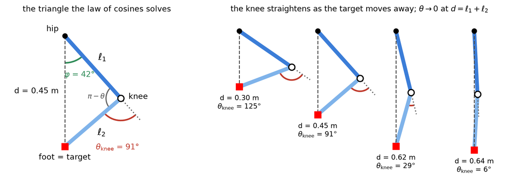

## What the closed form tells you

```
  d=0.02 m -> unreachable
  d=0.20 m -> knee angle  144.4 deg
  d=0.40 m -> knee angle  103.1 deg
  d=0.60 m -> knee angle   41.3 deg
  d=0.64 m -> knee angle    6.2 deg
  d=0.70 m -> unreachable
```

Three lessons in one table:

- Reachable distances form an **annulus**, not a disc — too close is as impossible as too far
- $\arccos$ returns one angle, but $-\theta$ works equally well: **two solutions**, knee-forward and knee-back. Humans use one of them; the mathematics does not care
- As $d$ approaches $\ell_1+\ell_2$ the knee straightens, and the sensitivity of angle to distance **diverges**

## Seen, not read

Differentiate the law of cosines and the sensitivity of angle to distance falls out with $\sin\theta$ in the denominator:

$${\color{#c0392b}{\left|\frac{d\theta}{d\,d}\right|}} = \frac{d}{\ell_1\,\ell_2\,\sin{\color{#3b7dd8}{\theta}}}$$

At full reach ${\color{#3b7dd8}{\theta}} \to 0$, $\sin{\color{#3b7dd8}{\theta}} \to 0$, and one millimetre of target asks for whole degrees of knee: blue is the angle, red its derivative.

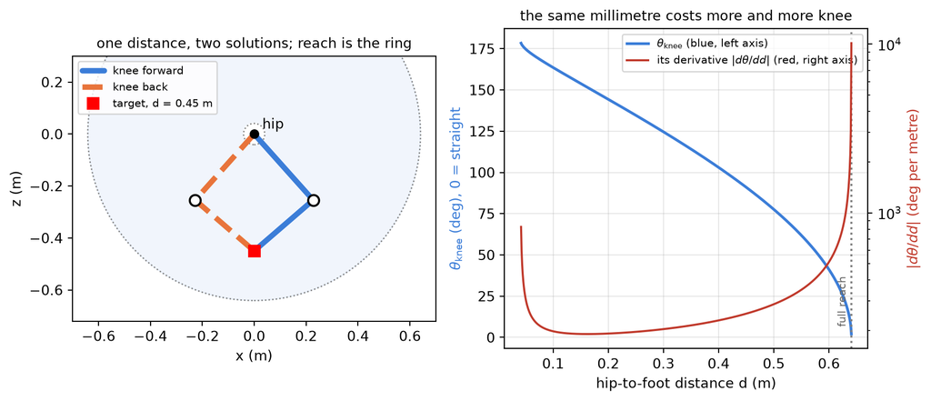

## Why we cannot stop there

The closed form handles two joints in a plane. A real foot pose is **six numbers** — three position, three orientation — and the leg has six joints.

Deriving closed-form IK for all six is possible, and it is:

- specific to this exact robot, and wrong for any other
- painful to extend when a joint limit or an obstacle intrudes
- brittle: a small model change invalidates the derivation

So we use a method that needs no derivation at all, works for any chain, and degrades gracefully when the problem is ill-posed.

## Differential IK

**Forward kinematics, in velocities** (last week’s Jacobian). Colour code for the rest of the week: **blue** is joint motion, **red** is foot motion, $J$ is the map between them:

$${\color{#c0392b}{\dot{\mathbf{x}}}} = J(q)\,{\color{#3b7dd8}{\dot{q}}}$$

- ${\color{#3b7dd8}{q}}$ — the vector of joint angles; ${\color{#3b7dd8}{\dot{q}}}$ — how fast each joint is turning
- ${\color{#c0392b}{\mathbf{x}}}$ — the foot (end-effector) position and orientation; ${\color{#c0392b}{\dot{\mathbf{x}}}}$ — how fast the foot moves
- $J(q)$ — the Jacobian: the matrix that turns joint speeds into foot speed, and changes with the pose

*If you know how fast the joints move, the Jacobian tells you how fast the foot moves.*

**Inverse kinematics asks the opposite:** *what joint motion produces the foot motion I want?* So do not solve for the angles. Solve for a small **change** in the angles that moves the foot toward the target, then repeat. Rearranged:

$$J\,{\color{#3b7dd8}{\Delta q}} = {\color{#c0392b}{\mathbf{e}}}$$

- ${\color{#c0392b}{\mathbf{e}}}$ — the desired foot motion: a small step toward the target
- ${\color{#3b7dd8}{\Delta q}}$ — the joint-angle change that produces that motion

## The obvious answer: ${\color{#3b7dd8}{\Delta q}} = J^{-1}{\color{#c0392b}{\mathbf{e}}}$

Six equations, six unknowns: for one leg $J$ is $6 \times 6$, so if it is invertible the system $J\,{\color{#3b7dd8}{\Delta q}} = {\color{#c0392b}{\mathbf{e}}}$ has exactly one solution,

$${\color{#3b7dd8}{\Delta q}} = J^{-1}\,{\color{#c0392b}{\mathbf{e}}}.$$

$J$ maps joint motion to foot motion; $J^{-1}$ runs that map backwards. Hand it the foot motion you want and it returns the joint motion that produces it — exactly, so that $J\,{\color{#3b7dd8}{\Delta q}} = {\color{#c0392b}{\mathbf{e}}}$ holds to machine precision.

What the inverse *costs* shows in the singular value decomposition. With $J = U\Sigma V^{\mathsf T}$, $J^{-1} = V\Sigma^{-1}U^{\mathsf T}$: each direction the foot can move is **divided by its own ${\color{#e8743b}{\sigma_i}}$**. A direction the leg barely moves (small ${\color{#e8743b}{\sigma_i}}$) needs $1/{\color{#e8743b}{\sigma_i}}$ of joint motion; at a singularity ${\color{#e8743b}{\sigma_i}} = 0$ and no solution exists — and just beside it, a huge one.

```
  crouch  sigma_min = 8.9e-02   |dq| =     0.5632 rad   |J dq - e| = 1e-17
  stand   sigma_min = 9.0e-07   |dq| =  5.578e+04 rad   |J dq - e| = 3e-13
```

Crouched, the inverse is a fine answer: half a radian, shared by hip, knee and ankle. Standing — the straight leg, $\sigma_{\min} \approx 10^{-6}$ — the same 5 cm request costs **tens of thousands of radians**, and the residual is still zero: the algebra *succeeded* and commanded the impossible. That is what the next slide damps.

## Damped least squares

Instead of demanding an exact solution, ask for a compromise: reduce the error *and* keep the joint motion small. One new number, the damping ${\color{#e8743b}{\lambda}}$, sets the trade:

$${\color{#3b7dd8}{\Delta q}} = J^{\mathsf{T}}\left(J J^{\mathsf{T}} + {\color{#e8743b}{\lambda^2}} I\right)^{-1}{\color{#c0392b}{\mathbf{e}}}$$

${\color{#e8743b}{\lambda}}$ trades accuracy against stability. Away from singularities it barely matters; near one it is the difference between a smooth motion and a violent lunge.

```
  lambda=0.0     |dq| =   55778.24 rad
  lambda=0.001   |dq| =       0.04 rad
  lambda=0.01    |dq| =       0.00 rad
  lambda=0.1     |dq| =       0.00 rad
```

## Where the formula comes from: the cost

Instead of *solving* $J\,{\color{#3b7dd8}{\Delta q}} = {\color{#c0392b}{\mathbf{e}}}$, ask for the ${\color{#3b7dd8}{\Delta q}}$ that **minimises a cost** with two terms — the error left over, and the joint motion spent:

$$C({\color{#3b7dd8}{\Delta q}}) = {\color{#c0392b}{\|J\,\Delta q - \mathbf{e}\|^2}} + {\color{#e8743b}{\lambda^2\,\|\Delta q\|^2}} .$$

**Step 1 — expand.** Using $\|v\|^2 = v^{\mathsf T}v$:

$$C = {\color{#c0392b}{\Delta q^{\mathsf T} J^{\mathsf T} J\,\Delta q \;-\; 2\,\mathbf{e}^{\mathsf T} J\,\Delta q \;+\; \mathbf{e}^{\mathsf T}\mathbf{e}}}
\;+\; {\color{#e8743b}{\lambda^2\,\Delta q^{\mathsf T}\Delta q}} .$$

**Step 2 — differentiate with respect to ${\color{#3b7dd8}{\Delta q}}$** (for a symmetric $A$, $\nabla\, v^{\mathsf T} A v = 2Av$ and $\nabla\, b^{\mathsf T} v = b$):

$$\nabla C = {\color{#c0392b}{2\,J^{\mathsf T} J\,\Delta q \;-\; 2\,J^{\mathsf T}\mathbf{e}}} \;+\; {\color{#e8743b}{2\lambda^2\,\Delta q}} .$$

**Step 3 — set it to zero.** The minimum satisfies the *normal equations*

$$\left(J^{\mathsf T} J + {\color{#e8743b}{\lambda^2}} I\right){\color{#3b7dd8}{\Delta q}} = J^{\mathsf T}{\color{#c0392b}{\mathbf{e}}}
\qquad\Longrightarrow\qquad
{\color{#3b7dd8}{\Delta q}} = \left(J^{\mathsf T} J + {\color{#e8743b}{\lambda^2}} I\right)^{-1} J^{\mathsf T}{\color{#c0392b}{\mathbf{e}}}.$$

It *is* the minimum, not just a stationary point: the Hessian $2(J^{\mathsf T}J + {\color{#e8743b}{\lambda^2}} I)$ is positive definite for any ${\color{#e8743b}{\lambda}} > 0$, because $v^{\mathsf T}J^{\mathsf T}Jv = \|Jv\|^2 \ge 0$ and ${\color{#e8743b}{\lambda^2}}\|v\|^2 > 0$. The same fact says the inverse **always exists** — even at a singularity, where $J^{-1}$ does not. That is the whole point of the second term.

## Where the formula comes from: two forms

$$J^{\mathsf T}\left(J J^{\mathsf T} + \lambda^2 I\right)
\;=\; J^{\mathsf T} J J^{\mathsf T} + \lambda^2 J^{\mathsf T}
\;=\; \left(J^{\mathsf T} J + \lambda^2 I\right) J^{\mathsf T}.$$

Multiply on the left by $(J^{\mathsf T}J + \lambda^2 I)^{-1}$ and on the right by $(JJ^{\mathsf T} + \lambda^2 I)^{-1}$:

$$\left(J^{\mathsf T} J + \lambda^2 I\right)^{-1} J^{\mathsf T}
\;=\; J^{\mathsf T}\left(J J^{\mathsf T} + \lambda^2 I\right)^{-1}.$$

Why keep both? For a $6 \times n$ Jacobian the left form inverts an $n \times n$ matrix and the right form a $6 \times 6$ one; with more joints than constraints the right form is the cheaper solve. For the leg, $n = 6$, and they cost the same.

## Where the formula comes from: each direction

**What the update does to each direction.** Write $J = U\,\Sigma\,V^{\mathsf T}$. Then $J^{\mathsf T}J + \lambda^2 I = V(\Sigma^2 + \lambda^2 I)V^{\mathsf T}$ and $J^{\mathsf T}\mathbf{e} = V\,\Sigma\,U^{\mathsf T}\mathbf{e}$, so

$${\color{#3b7dd8}{\Delta q}} = V\,\underbrace{(\Sigma^2 + {\color{#e8743b}{\lambda^2}} I)^{-1}\Sigma}_{\text{diagonal}}\;U^{\mathsf T}{\color{#c0392b}{\mathbf{e}}}$$

so direction $i$ is scaled by

$$\frac{\sigma_i}{\sigma_i^2 + {\color{#e8743b}{\lambda^2}}}
\approx \begin{cases} {\color{#2e8b57}{1/\sigma_i}} & \sigma_i \gg {\color{#e8743b}{\lambda}} \quad{\color{#2e8b57}{\text{the true inverse}}}\\[2pt]
{\color{#c0392b}{\sigma_i/\lambda^2 \to 0}} & \sigma_i \ll {\color{#e8743b}{\lambda}} \quad{\color{#c0392b}{\text{switched off}}}\end{cases}$$

${\color{#e8743b}{\lambda}}$ is a **threshold**: directions the Jacobian barely moves are ignored rather than amplified; the others get the true inverse. That is the whole trick.

```
  left form vs right form : 5.0e-12
  either form vs SVD form : 5.0e-12
  per-direction gain sigma/(sigma^2+lambda^2) vs the inverse's 1/sigma, at stand:
    sigma = 1.83e+00   damped      0.547   inverse      0.547
    sigma = 1.49e+00   damped      0.672   inverse      0.672
    sigma = 1.00e+00   damped          1   inverse          1
    sigma = 4.26e-01   damped       2.35   inverse       2.35
    sigma = 4.22e-01   damped       2.37   inverse       2.37
    sigma = 8.96e-07   damped      0.896   inverse   1.12e+06
```

## The same sweep, from both poses

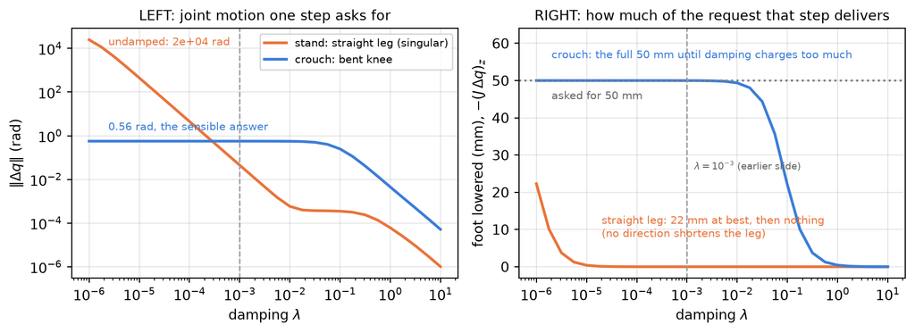

**Both panels share the x-axis**: the damping $\lambda$, swept from $10^{-6}$ (almost the plain inverse) to $10$, for the *same* request — lower the foot 5 cm — from two starting poses, orange standing, blue crouched. The grey dashed line is $\lambda = 10^{-3}$, the value used two slides ago.

## Reading the two panels

```
stand    undamped:  2.49e+04 rad ->  22.3 mm |  lambda=1e-4:  4.48 rad ->   0.0 mm |  1e-3:   0.0 mm |  1e-2:   0.0 mm |  1:  0.00 mm
crouch   undamped:  5.63e-01 rad ->  50.0 mm |  lambda=1e-4:  0.56 rad ->  50.0 mm |  1e-3:  50.0 mm |  1e-2:  49.4 mm |  1:  0.43 mm
```

- **Left — what one step asks of the joints**, $\|\Delta q\|$ on a log scale. Orange, the straight leg: tens of thousands of radians undamped, falling as $\lambda$ grows — by $10^{-4}$ a “sensible” 4.5 rad. Blue, the crouch: about half a radian, flat, until $\lambda \approx 10^{-2}$ starts to shrink it.
- **Right — what that step actually delivers**, how far the foot drops to first order. The dotted line is the 50 mm asked for. Blue delivers all of it for any $\lambda$ up to $10^{-3}$ and fades past $10^{-2}$; at $\lambda = 1$ it moves 0.4 mm per step — that fade is the price of damping. Orange never delivers: 22 mm at best undamped, nothing once damped, because the straight leg has no direction that shortens it and no $\lambda$ can create one.

**The lesson:** damping makes the *request* sane (left) but cannot invent a *direction* the pose lacks (right). The fix for the straight leg is a different starting pose, not a different $\lambda$.

## The condition number

Those numbers are not a quirk of the example. The `stand` keyframe has **every leg joint at exactly zero** — a perfectly straight leg.

```
stand pose: [0. 0. 0. 0. 0. 0.]
singular values, stand : [1.82956 1.48883 1.00031 0.42639 0.42172 0.     ]
smallest               : 8.96e-07   <- effectively zero
condition number stand  : sigma_max/sigma_min = 1.830 / 8.96e-07 = 2.04e+06   (log10 = 6.3 digits lost)
condition number crouch : sigma_max/sigma_min = 1.819 / 8.87e-02 = 2.05e+01   (log10 = 1.3 digits lost)
```

**What the condition number is.** $J$ sends every unit-length joint motion ($\|\dot q\| = 1$, a sphere in joint space) to a foot motion. The image is an **ellipsoid** whose semi-axes are the singular values $\sigma_1 \ge \dots \ge \sigma_6$, each along its own direction $u_i$ of foot space. The condition number is that ellipsoid’s aspect ratio:

$$\kappa(J) = \frac{\sigma_{\max}}{\sigma_{\min}} \qquad (1 \le \kappa \le \infty)$$

## Reading $\kappa$ three ways

- **Sensitivity.** One radian of joint motion buys $\sigma_{\max}$ metres of foot motion in the best direction and $\sigma_{\min}$ in the worst. Backwards, one millimetre of foot request costs $1/\sigma_{\min}$ of joint motion in the worst direction — **$\kappa$ times more** than in the best.
- **Error amplification.** For $\Delta q = J^{-1}\mathbf{e}$, a relative error in $\mathbf{e}$ becomes at most $\kappa$ times that relative error in $\Delta q$: $\|\delta\Delta q\|/\|\Delta q\| \le \kappa\,\|\delta\mathbf{e}\|/\|\mathbf{e}\|$. At $\kappa = 2 \times 10^6$, a target known to 0.1 mm in 50 mm (0.2 %) can come back as joint angles wrong by 4000 times their own size.
- **Digits.** $\log_{10}\kappa$ is roughly the number of significant digits the inverse can lose. $\kappa = 1$ is a pure rotation and loses none; the crouch, $\kappa \approx 20$, loses one of double precision’s sixteen; the straight leg loses six; $\kappa = \infty$ is a singular matrix — a rank gone, which is what $9 \times 10^{-7}$ is up to round-off.

## The ellipse the Jacobian draws

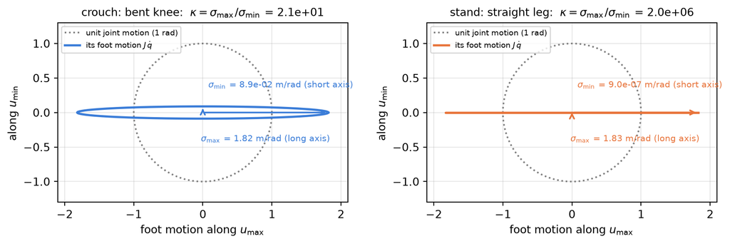

The dotted circle is every joint motion of one radian, taken in the plane of the best and the worst joint directions; the coloured curve is where $J$ sends it. Crouched, the ellipse is squashed about 20:1 — long along $u_{\max}$, short but *there* along $u_{\min}$, so a request in the short direction costs 20 times more joint motion and is still answerable. Standing, the ellipse has collapsed to a line: the axis that would shorten the leg is $10^{-6}$ long. A straight leg has **no direction that shortens it**. The Jacobian has lost a rank, undamped IK divides by nearly zero, and no amount of iteration helps — the information simply is not there.

## Six singular values, two poses

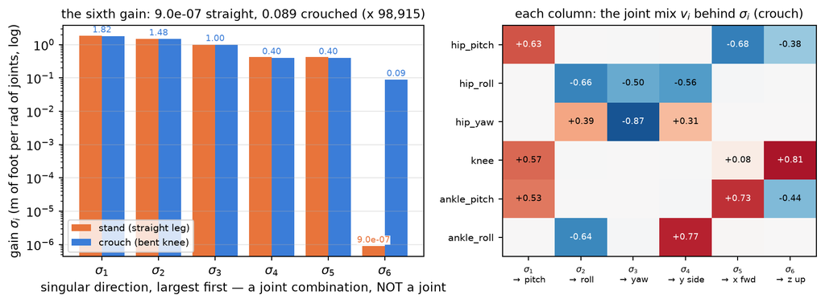

**The x-axis is not a list of joints.** Each bar is one *singular direction*: a joint combination $v_i$ — a column on the right, signs relative within the column — that $J$ turns into one foot-space direction $u_i$ (written under the column) with gain $\sigma_i$. Directions are ordered by gain, largest first.

The sixth column is $-0.38\,$hip pitch $+\,0.81\,$knee $-\,0.44\,$ankle pitch: bend the knee and pitch hip and ankle back so the foot stays level — the one motion that *shortens the leg* — and it moves the foot straight up or down ($u_6$ is pure $z$). The mix is the same in both poses; only the gain changes. Crouched, that combination buys 0.089 m per radian; straight, $9 \times 10^{-7}$ — a factor of a hundred thousand, restored by bending the knee. That one number is why every gait in the course starts from a crouch.

## The consequence, measured

Ask the solver to lower the pelvis 8 cm, from each of two seeds:

```
  straight-leg seed    residual error = 7.89e-01   knee = -0.087 rad
  crouched seed        residual error = 2.23e-06   knee = +1.015 rad
```

**The same request, the same solver, a different starting pose — and one of them simply cannot be solved.** This is why every gait in this course starts from a crouch, and why humans do not walk with locked knees.

## Reaching a target

With the crouch as a seed, IK is exact. Move the foot somewhere new:

```
requested : [0.15    0.11851 0.08314]
achieved  : [0.15    0.11851 0.08314]
error     : 1.29e-16 m
joint angles: [-0.546  0.    -0.     0.629 -0.083  0.   ]
```

Checked with **last week’s** forward kinematics, not with the solver’s own opinion of itself.

## Trace a circle

The real test of a solver is a whole path, not one point. Kinematics only — the robot is placed, never simulated:

```
90 targets, worst residual error = 8.37e-05 m
```

Stretch the circle vertically and the solver stops tracking — but only in one place:

```
worst residual 2.68e-03 m, at 279 degrees around the circle
```

**120 iterations changes nothing** — the error is identical at 12. That is the signature of a target that is *unreachable*, not one the solver ran out of time on. At the bottom of the circle the foot is asked to go below what the leg can reach with the pelvis where it is: the annulus from the start of the lecture, met from the outside.

A residual that will not shrink with more iterations is a **geometry** problem. Only a residual that shrinks slowly is a solver problem.

## Why exactly there

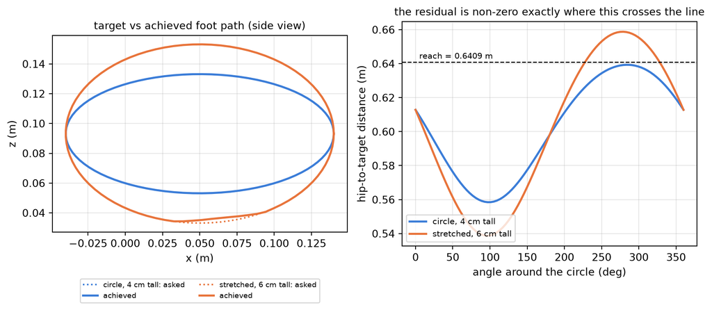

## Two habits worth keeping

**Warm starting.** Each solve begins from the previous answer. It converges in fewer iterations, and — more importantly — it picks the solution *near* the last one, so the leg does not flip between knee-forward and knee-back mid-path.

**Joint limits, every iteration.** The solver clamps after each step. Without that, IK cheerfully returns a mathematically perfect pose that the robot’s mechanical stops forbid.

Both matter next week, where this runs 500 times a second while the robot is actually falling forwards.

## What Week 4 does with this

You now have everything the walker needs:

| This week | Week 4 |
| --- | --- |
| Place a foot at a target | Place it on a planned footstep |
| Trace a path | Follow a swing trajectory |
| Pelvis given, legs solved | Pelvis follows the LIPM |
| Crouch to avoid singularity | Every gait starts crouched |
| Warm starting | 500 solves per second, each seeded by the last |

Next week the targets stop being ours to choose. They come from a **balance model**, and the robot walks.

## Lab class: on your laptop

```bash
uv run weeks/03-inverse-kinematics/lab_connected.py
```

**Ten problems, one score out of 10.** Wave, sway, twist, squat, bow, clap, both hands up, squat-wave, twist-wave, and a boss. You edit **only `moves.py`**: each answer is a *move*, a list of `(seconds, pose)` steps the G1 blends through **under real physics**.

A pose names joints in degrees, or uses this lecture’s solver: `"pelvis": [0, 0, -0.2]` lowers the body 20 cm and `ik_legs` finds the twelve leg angles that keep both feet planted.

| Key | Does |
| --- | --- |
| `1` … `9`, `0` | play a problem, with a live gauge (“left hand 1.12 m, need > 1.20”) |
| `E`, then `K` / `ENTER` | freeze and pose by slider; step through your move; print the pose to paste |
| `G` | grade all ten; the score and a 4-letter scorer code stay on screen |

`moves.py` ships with its key numbers left as `...` — fill them in. It is re-read on every key press: save, press again, no restart.

## Lab class: what the game teaches

Every pose in the game is one IK solves perfectly — frozen. **Under gravity, half of them fall over.** Measured with the game’s own `--grade`:

| Problem | The naive answer | What works |
| --- | --- | --- |
| Hands up | both arms at once: falls on its face | one arm, then the other: 1.36 m |
| Clap | arms forward: falls forward | pelvis 4 cm back as a counterweight |
| Bow | hips −30°, waist +30°: topples | push the pelvis back and down while bending |
| Boss | lower the arms, then stand: falls on its back | stand up *first*, arms still up |

**Kinematics places a pose; it does not balance a robot.** The order of the poses is part of the answer. That gap is weeks 4 and 5.

A pass needs three things: the goal reached, no fall on the way, and the robot ends standing. Take as long as you like — slow moves often balance.

## Exercises

1. **Both elbows.** The knee has two solutions. Force the other one by seeding with a negative knee angle. Does the solver find it, and does the foot end up in the same place?
2. **Out of reach.** Ask for a foot target 0.8 m from the hip. What does the residual error do, and what pose does the solver settle into?
3. **Damping sweep.** Trace the circle with $\lambda = 0$ and $\lambda = 1$. Compare worst-case error against the largest single joint step.
4. **No warm start.** Re-seed every solve from the crouch instead of the previous pose. Watch for discontinuities in the joint trajectories, and plot them.
5. **Wrong anchor.** Feed IK a target orientation tilted 20° from flat. Is it reachable? What does that imply about walking on a slope?
6. **Count the iterations.** Instrument `ik_legs` to report iterations used per solve along the circle. Where on the path is it working hardest, and why?

## Next week

**04 — the robot walks.** Footstep planning, the linear inverted pendulum, and the analytic gait that carries a 29-DOF humanoid across the floor with no learning of any kind.

Bring the crouch.